# SNAP Eligibility Microsimulation

## Overview

This file is fully self-contained. It loads all data from scratch, builds household-level SNAP filing units, defines a vectorized eligibility function, and runs baseline and counterfactual policy scenarios.

## Libraries

```r
library(tidyverse)
library(readxl)
library(data.table)
library(bit64)
```

## Load SNAP Policy Database

```r
snapdb <- read_xlsx("data/SNAPPolicyDatabase.xlsx", sheet = "SNAP Policy Database") |>
  filter(yearmonth == 201907) |>
  select(starts_with("state"), starts_with("bbce"), starts_with("veh"))

# Work requirement tiers based on FY2019 Q4 ABAWD waiver status
state_exempt <- c("Alaska", "District of Columbia", "Louisiana", "New Mexico")

state_nonexempt <- c("Alabama", "Arkansas", "Delaware", "Florida", "Indiana",
                     "Iowa", "Kansas", "Maine", "Mississippi", "Missouri",
                     "Nebraska", "North Carolina", "Oklahoma", "South Carolina",
                     "Texas", "Wisconsin", "Wyoming")

snapdb <- snapdb |>
  mutate(work_req = case_when(
    statename %in% state_exempt ~ "full_exemption",
    statename %in% state_nonexempt ~ "no_exemption",
    TRUE ~ "partial_exemption"))
```

## Load SIPP 2019

```r
ds <- "data/pu2019.csv"

all_cols <- names(fread(ds, sep = "|", nrows = 0))

exact_vars <- c(
  # ID variables
  'SSUID', 'PNUM', 'MONTHCODE', 'ERESIDENCEID', 'ERELRPE', 'SPANEL', 'SWAVE',
  'SHHADID', 'THHLDSTATUS', 'RIN_UNIV',

  # Base weight
  'WPFINWGT',

  # State of residence
  'TEHC_ST', 'TST_INTV',

  # Demographics
  'ESEX', 'TAGE', 'TAGE_EHC', 'ERACE', 'EORIGIN', 'EEDUC',
  'ECITIZEN', 'ENATIVITY', 'EIMM_STAT', 'TIMSTAT', 'TYRENTRY',
  'EDISABL', 'RDIS', 'RDIS_ALT',

  # Household structure
  'TLIVQTR', 'ETENURE', 'EMS',

  # Income
  'TPTOTINC', 'TPEARN', 'TFTOTINC',
  'TUNEMP_AMT', 'TSSI_AMT', 'TSSRX', 'TSSXAMT', 'TTANF_AMT',

  # Deductions
  'TAMOUNTPAID', 'TPAYWK', 'TRENTMORT', 'TUTILS', 'THVAL_RMU',
  'TCHCARE_AMT', 'TMDPAY',

  # Assets (individual-level; shared assets divided equally)
  'TVAL_AST', 'TVAL_BANK', 'TVAL_BOND', 'TVAL_BUS', 'TVAL_ESAV',
  'TVAL_HOME', 'TVAL_RENT', 'TVAL_RE', 'TVAL_RET',
  'TVAL_STMF', 'TVAL_VEH', 'TVAL_OTH',

  # Program participation
  'RFSCOV', 'RSNAP_MNYN', 'RTANF_MNYN', 'RSSI_MNYN', 'RWICYN',

  # ABAWD work requirement variables
  'TMWKHRS', 'EWELACTV2_1', 'EWELACTV2_2', 'EWELACTV2_3', 'EWELACTV4'
)

patterns <- c(
  "^RREL", "^ET2REL", "^SNAP", "^TEHC",
  "^EOWN", "^EJSOWN", "^EJOOWN", "^EOOWN",
  "^TJS", "^TJO", "^VAL", "^EVEH", "^TVEH"
)

pattern_vars <- unique(unlist(lapply(patterns, function(p) grep(p, all_cols, value = TRUE))))
keep_vars    <- unique(c(exact_vars, pattern_vars))
keep_vars    <- keep_vars[keep_vars %in% all_cols]

pu <- fread(ds, sep = "|", select = keep_vars)
names(pu) <- toupper(names(pu))

dw <- "data/rw2019.csv"
rw <- fread(dw, sep = "|")
names(rw) <- toupper(names(rw))

sipp2019 <- left_join(pu, rw, by = c("SSUID", "PNUM", "MONTHCODE"))
```

## Filter to July 2019 and generate new SNAP unit ID

Households are uniquely identified by SSUID and SHHADID, but some households may contain multiple SNAP units, defined as people who live and purchase food together. The SIPP does not directly ask about this, but we approximate it based on household relationships. We assume that family members and partners living together are part of the same SNAP unit, while roommates/boarders/other non-family members are not.

```r
sipp_0719 <- sipp2019 |>
  filter(RIN_UNIV == 1 & MONTHCODE == 7) |>
  mutate(hhid = paste0(as.character(SSUID), as.character(SHHADID))) |>
  group_by(hhid) |>
  mutate(snap_split = ERELRPE %in% 16:18, # splitting cases that are roommates/boarders/other non-family into separate SNAP unit
         split_id = if_else(snap_split, cumsum(snap_split), NA_integer_),
         snapuid = case_when(!snap_split ~ 1,
         snap_split ~ split_id + 1)
) |> ungroup() |>
  mutate(snap_hhid = paste0(hhid, snapuid))

# Brief checks to make sure split went correctly
sipp_0719 |>
  group_by(hhid) |>
  summarise(n_snap_units = n_distinct(snap_hhid)) |>
  count(n_snap_units)
```

```
# A tibble: 8 × 2
  n_snap_units     n
         <int> <int>
1            1 20191
2            2   533
3            3   112
4            4    36
5            5    14
6            6     6
7            7     1
8            8     1
```

```r
sipp_0719 |>
  group_by(hhid) |>
  filter(n_distinct(snap_hhid) > 1) |>
  arrange(hhid, snap_hhid) |>
  select(hhid, ERELRPE, snap_hhid) |>
  ungroup() |>
  slice_head(n = 50)
```

```
# A tibble: 50 × 3
   hhid             ERELRPE snap_hhid
   <chr>              <int> <chr>
 1 2850346461811          2 28503464618111
 2 2850346461811         16 28503464618112
 3 2920499955501811       2 29204999555018111
 4 2920499955501811      18 29204999555018112
 5 2921360681981811       1 29213606819818111
 6 2921360681981811       4 29213606819818111
 7 2921360681981811       7 29213606819818111
 8 2921360681981811      18 29213606819818112
 9 2921363345521811       1 29213633455218111
10 2921363345521811       7 29213633455218111
# ℹ 40 more rows
```

## FPL and Deduction Limits

In this section we set the baseline federal poverty limit (FPL), standard deduction, and maximum shelter deductions set by the USDA FNS.

For each SNAP household, we find the 2019 federal poverty level using the The U.S. Department of Health and Human Service’s published guidelines, divided by 12 to specifically capture monthly poverty level. (HHS 2019). We use a vectorized approach for baseline FPL limits, which then allows us to modify them to set limit simulations later on. While, Alaska, Guam, and Hawaii have varying FPL limits, to capture their differential costs of living, given their small sample size in the SIPP, we did not include their specific FPL’s. The standard deduction and shelter deduction are set by FNS (FNS 2018)

```r
# 2019 monthly FPL (contiguous 48 states and DC)
fpl_monthly    <- c(1041, 1410, 1778, 2146, 2515, 2883, 3251, 3620)
fpl_additional <- 369

# 2019 standard deductions by household size (caps at 6)
std_ded_tbl <- c(164, 164, 164, 174, 204, 234)

# Excess shelter deduction cap for non-elderly/disabled households
shelter_cap <- 552

get_fpl <- function(n){
  fpl_monthly[pmin(n, 8)] + pmax(n - 8, 0) * fpl_additional
}
get_std_ded <- function(n){
  std_ded_tbl[pmin(n, 6)]
}
```

## Aggregate to Household-Level SNAP Filing Units

The proceeding code in this section collapses the individual to a group level of analysis (SNAP Household) Then at the household level we create every variable, usually either a binary flag (TRUE or FALSE) or continuous limit needed to determine that household’s SNAP eligibility. In this section we do not fully determine whether a household is eligible just simply flag, data needed for determination.

There are 5 sets of determinations we make at this stage:

1. **Composition:** number of members of household and whether there is someone who is elderly or disabled in the household. Flags for citizenship and state of residence are also included.
2. **Categorical Eligibility:** whether all members of the family receive TANF or SSI.
3. **Income and Assets:** the sum of gross income, earned income, countable assets, and vehicle assets.
4. **Deductions** (case-specific): whether the household had any child support payments, child care costs, or out-of-pocket medical expenses.
5. **ABAWD (Able-Bodied Adults without Dependents):** whether the household has children, their ages, whether adults works, how old they are, and how much they work per week.

It’s important to note the SIPP is very well known for under counting income information (Meyer, Mok, and Sullivan 2015). As such we decided for the purposes of this microsimulation exercise to apply a modest income-multiplier to account for these instances.

Given that we construct our own SNAP households based on SNAP methodology (based on those who share food rather than the SIPP furnished household ID), we use the SIPP User Guide’s recommendation to create household weights by simply taking a reference person’s weight to represent the SNAP household (US Census Bureau 2024).

```r
# Aggregation
hh_sipp <- sipp_0719 |>
  group_by(snap_hhid) |>
  summarize(
    hh_size = n(),
    has_elderly = any(TAGE >= 60, na.rm = TRUE),
    has_disabled = any(RDIS == 1, na.rm = TRUE),
    has_ssi = all(RSSI_MNYN == 1, na.rm = TRUE),
    has_tanf = all(RTANF_MNYN == 1, na.rm = TRUE),
    # Income
    hh_gross_inc = sum(TPTOTINC, na.rm = TRUE) * 1.25, # sipp undercounts apply this factor
    hh_earn = sum(TPEARN, na.rm = TRUE) * 1.25, # sipp undercounts apply this factor
    # Deductions
    child_sup_ded = sum(TAMOUNTPAID, na.rm = TRUE),
    child_care_ded = sum(TPAYWK, na.rm = TRUE) * 4,
    medical_costs = sum(TMDPAY, na.rm = TRUE),
    # Shelter (December of reference year as proxy)
    shelter_costs = coalesce(first(na.omit(THVAL_RMU)), 0),
    # Countable assets
    countable_assets = sum(TVAL_BANK, na.rm = TRUE) + sum(TVAL_BOND, na.rm = TRUE) +
                       sum(TVAL_BUS,  na.rm = TRUE) + sum(TVAL_STMF, na.rm = TRUE) +
                       sum(TVAL_RENT, na.rm = TRUE) + sum(TVAL_RE,   na.rm = TRUE) +
                       sum(TVAL_OTH,  na.rm = TRUE),
    vehicle_assets = sum(TVAL_VEH, na.rm = TRUE),
    tveh1_val = first(TVEH1VAL),
    tveh2_val = first(TVEH2VAL),
    # ABAWD flags
    has_children = any(TAGE < 18, na.rm = TRUE),
    youngest_child_age = if (any(TAGE < 26, na.rm = TRUE))
                           as.numeric(min(TAGE[TAGE < 26], na.rm = TRUE))
                         else NA_real_,
    has_abawd_age = any(TAGE >= 18 & TAGE <= 49 & # baseline 18-49 flag
                       (is.na(RDIS) | RDIS != 1), na.rm = TRUE),
    has_adult_nondis_50_59 = any(TAGE >= 50 & TAGE <= 59 &
                                (is.na(RDIS) | RDIS != 1), na.rm = TRUE),
    has_adult_nondis_60_65 = any(TAGE >= 60 & TAGE <= 65 &
                                (is.na(RDIS) | RDIS != 1), na.rm = TRUE),
    max_work_hrs = max(c(0, TMWKHRS[TAGE >= 18 &
                       (is.na(RDIS) | RDIS != 1)]), na.rm = TRUE),
    has_cit_or_elig_noncit = any(ECITIZEN == 1 | (TIMSTAT == 1 & TYRENTRY <= 2014), na.rm = TRUE),
    state_fips = first(TEHC_ST),
    weight = first(WPFINWGT[!is.na(ERELRPE) & ERELRPE == min(ERELRPE, na.rm = TRUE)]),
    snap_actual = any(RSNAP_MNYN == 1, na.rm = TRUE)
  )
```

## Describing the Aggregated SNAP Household Data

We examine the distribution of household gross income in the data for all households, and households actually receiving SNAP

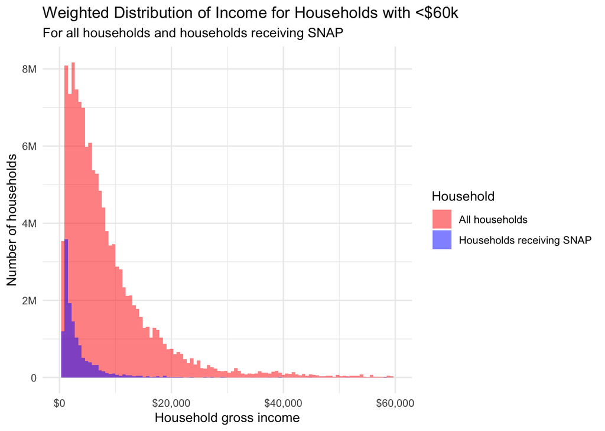

```r
library(scales)
# Limit to households earning less than $60k gross income for aesthetic purposes
inc_cutoff <- hh_sipp |>
  filter(hh_gross_inc <= 60000)
ggplot() +
  # All households earning less than $60k
  geom_histogram(data = inc_cutoff,
                 mapping = aes(x = hh_gross_inc, weight = weight,
                               fill = "All households"),
                 bins = 100, alpha = 0.5) +
  # Households receiving SNAP
  geom_histogram(data = subset(hh_sipp, snap_actual == TRUE),
                 mapping = aes(x = hh_gross_inc, weight = weight,
                               fill = "Households receiving SNAP"),
                 bins = 100, alpha = 0.5) +
  scale_fill_manual(values = c("All households" = "red",
                      "Households receiving SNAP" = "blue")) +
  scale_y_continuous(labels = label_number(scale_cut = cut_short_scale())) +
  scale_x_continuous(limits = c(0, 60000),
                     labels = dollar_format(prefix = "$")) +
  labs(title = "Weighted Distribution of Income for Households with <$60k",
       subtitle = "For all households and households receiving SNAP",
       x = "Household gross income", y = "Number of households",
       fill = "Household") +
  theme_minimal()
```

The income distribution is heavily right skewed. The gross income distribution of SNAP households has the same shape as for all households, but the overall distribution is more concentrated on the left, as we expect. Next we examine the distribution of countable assets for all households in the data (savings, stocks, money market accounts).

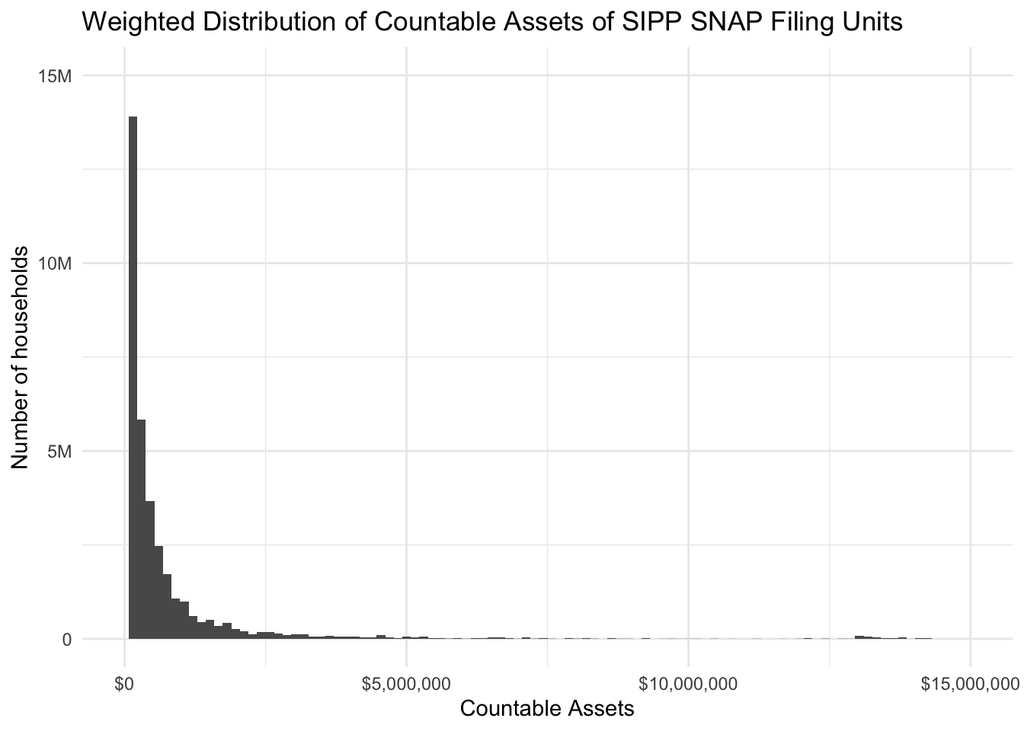

```r
hh_sipp |>
  ggplot() +
  geom_histogram(mapping = aes(x = countable_assets, weight = weight),
                 bins = 100) +
  scale_y_continuous(limits = c(0, 15000000),
                     labels = label_number(scale_cut = cut_short_scale())) +
  scale_x_continuous(limits = c(0, 15000000),
                     labels = dollar_format(prefix = "$")) +
  labs(title = "Weighted Distribution of Countable Assets of SIPP SNAP Filing Units",
       x = "Countable Assets", y = "Number of households") +
  theme_minimal()
```

The distribution of countable assets is more heavily right skewed, and with a much longer tail. Next we visualize the number of adults in the data that meet or don’t meet the ABAWD work requirement.

```r
abawd_summary <- hh_sipp |>
  mutate(
    abawd_status = case_when(
      has_ssi | has_tanf ~ "Exempt: SSI/TANF",
      !has_abawd_age ~ "Exempt: Age out of range",
      !is.na(youngest_child_age) & youngest_child_age < 18 ~ "Exempt: Has qualifying dependent",
      has_abawd_age & max_work_hrs >= 20 ~ "ABAWD: Meets work requirement",
      has_abawd_age & max_work_hrs < 20 ~ "ABAWD: Does not meet requirement",
      TRUE ~ "Other"
    ),
    top_level = if_else(str_starts(abawd_status, "ABAWD"), "Has ABAWD", "No ABAWD")
  ) |>
  group_by(top_level, abawd_status) |>
  summarize(n_weighted = sum(weight, na.rm = TRUE), .groups = "drop") |>
  mutate(share = n_weighted / sum(n_weighted))
abawd_summary
```

```
# A tibble: 5 × 4
  top_level abawd_status                     n_weighted  share
  <chr>     <chr>                                 <dbl>  <dbl>
1 Has ABAWD ABAWD: Does not meet requirement   6116051. 0.0447
2 Has ABAWD ABAWD: Meets work requirement     33026136. 0.241
3 No ABAWD  Exempt: Age out of range          62127675. 0.454
4 No ABAWD  Exempt: Has qualifying dependent  32086243. 0.234
5 No ABAWD  Exempt: SSI/TANF                   3483288. 0.0255
```

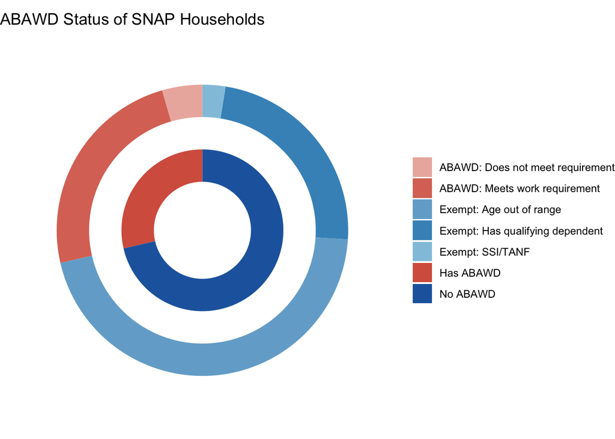

```r
# Inner ring - top level
inner <- abawd_summary |>
  group_by(top_level) |>
  summarize(share = sum(share))
# Outer ring - subsections
outer <- abawd_summary
# Colors
colors <- c("Has ABAWD" = "#d6604d",
            "ABAWD: Meets work requirement" = "#db7464",
            "ABAWD: Does not meet requirement" = "#ecb5ac",
            "No ABAWD" = "#2166ac",
            "Exempt: SSI/TANF" = "#92c5de",
            "Exempt: Age out of range" = "#74add1",
            "Exempt: Has qualifying dependent" = "#4393c3")
ggplot() +
  # Inner ring
  geom_col(data = inner,
           aes(x = 1, y = share, fill = top_level),
           width = 0.5) +
  # Outer ring
  geom_col(data = outer,
           aes(x = 2, y = share, fill = abawd_status),
           width = 0.5) +
    scale_fill_manual(values = colors) +
  coord_polar(theta = "y") +
  xlim(0, 2.5) +
  theme_void() +
  labs(title = "ABAWD Status of SNAP Households",
       fill = NULL)
```

Most SNAP households in our data are exempt from ABAWD requirements, mainly for being out of the age range. About 1/4 of households have an adult that would likely qualify for the ABAWD restrictions, and of those households, the qualification is mostly from meeting the work requirement.

## Eligibility Function

The goal of this section is to estimate national SNAP household eligibility under various sets of simulations. Fundamentally this section accomplishes two things.

First, we code three broad categories of policy baselines into the function arguments which can then be modified for simulation. These are income, asset, and ABAWD work policy baselines. Most of these simply just restate the federal guidelines.

- **Income**: sets the national gross income limit to 130% of FPL and net income limit to 100% of FPL.
  - Net Income is calculated by subtracting a 20% earned income deduction, a standard deduction, child support/ care costs, excess shelter deduction (housing above 50% of net income, but capped), and medical expenses (elderly and disabled only). Additionally it adjust gross limits for states with broad based categorical eligibility.
- **Asset**: keeps each state’s and the federal asset limit intact. The federal default for assets is $2250 and vehicle assets are counted using state rules.
- **ABAWD**: The federal requirement for ABAWD requirements are non-disabled adults aged 18–49 without dependent children must work at least 20 hours per week unless their state has a work exemption. HH’s that receive SSI or TANF are exempt. The simulation allows the ABAWD age ceiling, minimum hours, and dependent child age cutoff to be varied as policy parameters.

As such simply applying a data frame to the baseline function, produces a baseline SNAP household eligibility simulation.

Secondly, using these baseline levels and the argumentation described within the code to 5 categories of eligibility which need to be met for SNAP. **Basically they must be income, asset, work, and citizen eligible. Or they must meet categorically eligibility and be work and citizen eligible.**

- Categorical Eligibility: Households where all members receive either SSI or TANF automatically pass income and asset tests.
- Income Eligible (adjusted for BBCE): households must pass both a gross income test a net income test as described earlier, but states with BBCE adjust these limits.
- Asset Eligibility: Countable assets including accounts, bonds, stocks, vehicles, etc must be below an applicable limit which varies by state, although there are federal limits.
- Work Eligibility: Basically the process described earlier.
- Citizen Eligibility: At least one householder must be a U.S citizen or legal permanent resident who entered the country at least 5 years ago.

```r
# SNAP Eligibility determination
snap_elig_sim <- function(df,
    # Note all of these can be changed as simulations: Income
    gross_pct = 1.30,     # gross income limit as fraction of FPL (federal default: 1.30)
    net_pct = 1.00,     # net income limit as fraction of FPL   (federal default: 1.00)
    use_bbce= TRUE,     # apply state BBCE income extensions
    # Asset
    elim_asset = FALSE,  # TRUE = no asset test for anyone
    asset_limit = NULL,   # set a uniform asset limit in dollars; NULL = federal/BBCE default
    # Work
    work_req = NULL, # NULL = use state rules; "full_exemption"; "no_exemption"
    abawd_max_age = 49,   # upper age of ABAWD range (federal default: 49)
    min_work_hrs = 20,   # minimum weekly hours to meet work requirement
    dep_age = 18    # child must be under this age to exempt adult from ABAWD
) { with(df,
         {
  # State snap policy
  sp <- snapdb[match(state_fips, snapdb$state_fips), ]

  # FPL thresholds
  fpl       <- get_fpl(hh_size)
  gross_lmt <- fpl * gross_pct
  net_lmt   <- fpl * net_pct
  fed_asset_lmt <- if_else(has_elderly | has_disabled, 3500, 2250)
  if (!is.null(asset_limit)) fed_asset_lmt <- rep(asset_limit, length(hh_size))

  # Net income calculation
  std_ded <- get_std_ded(hh_size)
  earn_ded <- hh_earn * 0.20
  net_pre_shelter <- pmax(hh_gross_inc - std_ded - earn_ded - child_sup_ded - child_care_ded, 0)
  shelter_excess  <- pmax(shelter_costs - 0.50 * net_pre_shelter, 0)
  shelter_ded <- if_else(has_elderly | has_disabled,
                             shelter_excess, pmin(shelter_excess, shelter_cap))
  medical_ded <- if_else(has_elderly | has_disabled, pmax(medical_costs - 35, 0), 0)
  net_inc <- pmax(net_pre_shelter - shelter_ded - medical_ded, 0)

  # Categorical eligibility (SSI/TANF bypasses income and asset tests)
  cat_elig <- has_ssi | has_tanf

  # BBCE — look up from state policy; disabled when use_bbce = FALSE
  bbce_on <- use_bbce & !is.na(sp$bbce) & sp$bbce == 1
  bbce_applies <- bbce_on & !(coalesce(sp$bbce_child, 0L) == 1L & !has_children)

  gross_lmt_bbce <- if_else(bbce_applies & coalesce(sp$bbce_inclmt, -9L) > 0,
                             fpl * (sp$bbce_inclmt / 100), gross_lmt)
  gross_lmt_eld <- if_else(bbce_applies & coalesce(sp$bbce_elddisinclmt, -9L) > 0,
                             fpl * (sp$bbce_elddisinclmt / 100), gross_lmt_bbce)
  gross_lmt_eff <- if_else(has_elderly | has_disabled, gross_lmt_eld, gross_lmt_bbce)

  asset_test_on <- !(bbce_applies & !is.na(sp$bbce_asset) & sp$bbce_asset == 1)
  asset_lmt_eff <- case_when(
    bbce_applies & coalesce(sp$bbce_a_amt, 0) > 0 ~ sp$bbce_a_amt * 1000,
    TRUE ~ fed_asset_lmt
  )
  if (elim_asset) asset_test_on <- rep(FALSE, length(hh_size))

  # Vehicle countable value — look up state vehicle exclusion rules
  vehicle_countable <- case_when(
    sp$vehexclall == 1 ~ 0,
    sp$vehexclone == 1 ~ pmax(vehicle_assets - coalesce(tveh1_val, 0), 0),
    TRUE ~ vehicle_assets
  )
  net_worth <- countable_assets + vehicle_countable

  # Eligibility tests
  gross_elig <- (has_elderly | has_disabled) | hh_gross_inc <= gross_lmt_eff
  net_elig   <- net_inc      <= net_lmt
  asset_elig <- !asset_test_on | cat_elig | (net_worth <= asset_lmt_eff)

  eff_work_req <- if (!is.null(work_req)) rep(work_req, length(hh_size)) else sp$work_req
  has_abawd_age_eff  <- has_abawd_age |
                        (abawd_max_age >= 55 & has_adult_nondis_50_59) |
                        (abawd_max_age >= 60 & has_adult_nondis_60_65)
  has_qualifying_dep <- !is.na(youngest_child_age) & youngest_child_age < dep_age
  meets_work_eff <- max_work_hrs >= min_work_hrs
  has_abawd <- has_abawd_age_eff & !has_qualifying_dep & !has_ssi & !has_tanf
  work_elig <- eff_work_req == "full_exemption" | !has_abawd | meets_work_eff

  citizen_elig <- coalesce(has_cit_or_elig_noncit, TRUE) | cat_elig

  (cat_elig | (gross_elig & net_elig)) & asset_elig & work_elig & citizen_elig
})}
```

## Scenario Functions

Now that we have our function to simulate SNAP eligibility, we create a function to run different SNAP policy scenarios, which will allow us to estimate how eligibility rates change as aspects of SNAP policy are adjusted. We also write a function to summarize scenarios and calculate the number of eligible SNAP households under different policies.

```r
run_scenario <- function(data, scenario_name, ...) {
  data |>
    mutate(snap_eligible = snap_elig_sim(pick(everything()), ...),
           scenario = scenario_name)
}

summarize_scenario <- function(data) {
  data |>
    ungroup() |>
    summarize(
      scenario = first(scenario),
      n_eligible_weighted = sum(snap_eligible * weight, na.rm = TRUE),
      n_total_weighted = sum(weight, na.rm = TRUE),
      pct_eligible= round(sum(snap_eligible * weight, na.rm = TRUE) /
                           sum(weight, na.rm = TRUE) * 100, 1))
}
```

## Run Scenarios

Here, we start by running our baseline scenario for the year and month we have chosen (July 2019). This is our baseline for calculating percent changes in eligibility under the other scenarios.

**Income.** We have two policy scenarios that adjust how much income is needed to qualify for SNAP. First, we change the gross income limit to 200% of the federal poverty line (FPL). Then, remove broad-based categorical eligibility (BBCE).

**Assets.** We have two scenarios that adjust asset limits for SNAP eligibility: eliminating the asset test, and raising the asset limit to $10,000.

**Work requirements.** There are several work requirements for SNAP eligibility, and we estimate how rates would change if the following policies were adopted with respect to work requirements: waive ABAWD, fully enforce ABAWD, require a minimum of 30 hours/week, make the dependent age cutoff 5 years old, and apply ABAWD to individuals aged 18-65.

```r
# Baseline: 2019 state rules as-is
baseline <- run_scenario(hh_sipp, "Baseline (2019)")

# Income
income_200pct  <- run_scenario(hh_sipp, "Gross limit 200% FPL",
                               gross_pct = 2.00)

income_no_bbce <- run_scenario(hh_sipp, "Federal rules only (no BBCE)",
                               use_bbce = FALSE)

# Assets
asset_elim <- run_scenario(hh_sipp, "Eliminate asset test",
                           elim_asset = TRUE)

asset_10k  <- run_scenario(hh_sipp, "Raise asset limit to $10k",
                           asset_limit = 10000)

# Work requirement scenarios
work_waive <- run_scenario(hh_sipp, "Waive ABAWD nationally",
                             work_req = "full_exemption")

work_enforce <- run_scenario(hh_sipp, "Enforce ABAWD nationally",
                             work_req = "no_exemption")

work_30hrs <- run_scenario(hh_sipp, "30-hour requirement", min_work_hrs = 30)

work_dep5    <- run_scenario(hh_sipp, "Dep age cutoff 5", dep_age = 5)

work_age65 <- run_scenario(hh_sipp, "ABAWD age 18-65", abawd_max_age = 65)
```

## Results

```r
results <- bind_rows(
  summarize_scenario(baseline),
  summarize_scenario(income_200pct),
  summarize_scenario(income_no_bbce),
  summarize_scenario(asset_elim),
  summarize_scenario(asset_10k),
  summarize_scenario(work_waive),
  summarize_scenario(work_enforce),
  summarize_scenario(work_30hrs),
  summarize_scenario(work_dep5),
  summarize_scenario(work_age65),
) |>
  mutate(
    change_from_baseline = n_eligible_weighted - n_eligible_weighted[scenario == "Baseline (2019)"],
    pct_change = round(100 * change_from_baseline / n_eligible_weighted[scenario == "Baseline (2019)"], 1)
  )

results
```

```
# A tibble: 10 × 6
   scenario                    n_eligible_weighted n_total_weighted pct_eligible
   <chr>                                     <dbl>            <dbl>        <dbl>
 1 Baseline (2019)                       26516024.       136839394.         19.4
 2 Gross limit 200% FPL                  26646891.       136839394.         19.5
 3 Federal rules only (no BBC…           17122789.       136839394.         12.5
 4 Eliminate asset test                  29975445.       136839394.         21.9
 5 Raise asset limit to $10k             26777053.       136839394.         19.6
 6 Waive ABAWD nationally                30001235.       136839394.         21.9
 7 Enforce ABAWD nationally              26392196.       136839394.         19.3
 8 30-hour requirement                   25992535.       136839394.         19
 9 Dep age cutoff 5                      25206410.       136839394.         18.4
10 ABAWD age 18-65                       24635126.       136839394.         18
# ℹ 2 more variables: change_from_baseline <dbl>, pct_change <dbl>
```

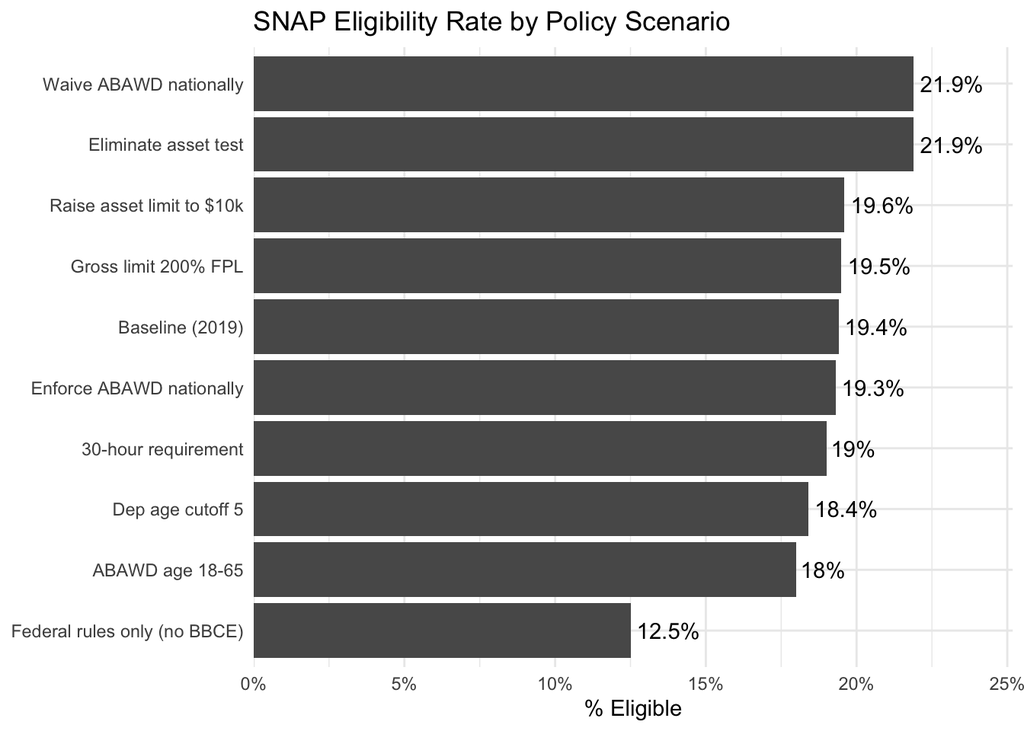

```r
results |>
  ggplot(aes(reorder(scenario, pct_eligible), pct_eligible)) +
  geom_col() +
  geom_text(aes(label = paste0(pct_eligible, "%")), hjust = -0.1) +
  coord_flip() +
  scale_y_continuous(
    expand = expansion(mult = c(0, 0.15)),
    labels = scales::label_percent(scale = 1)) +
  labs(
    title = "SNAP Eligibility Rate by Policy Scenario",
    x = NULL,
    y = "% Eligible") +
  theme_minimal()
```

### Baseline Income Distribution of SNAP eligibility

**Income Decile:**

First we want to understand the underlying income distribution of SNAP households to be able to model how this changes under various policy specifications. We first look at income decile eligibility distribution.

```r
distributional_table <- baseline |>
  mutate(inc_decile = ntile(hh_gross_inc, n = 10)) |>
  group_by(inc_decile) |>
  summarize(
    min_income = min(hh_gross_inc),
    max_income = max(hh_gross_inc),
    pct_eligible = round(weighted.mean(snap_eligible, weight, na.rm = TRUE) * 100, 1),
    n_eligible_weighted = sum(snap_eligible * weight, na.rm = TRUE)
  )

distributional_table
```

```
# A tibble: 10 × 5
   inc_decile min_income max_income pct_eligible n_eligible_weighted
        <int>      <dbl>      <dbl>        <dbl>               <dbl>
 1          1     -9381.      1086.         68.1            9583994.
 2          2      1086.      2085          57              7002765.
 3          3      2085       3094.         28.3            3672419.
 4          4      3094.      4192.         15.7            2097233.
 5          5      4192.      5475          10.4            1361787.
 6          6      5475       6952.          7.5            1006978.
 7          7      6952.      8900           5.4             743985.
 8          8      8900      11818.          3.9             554775.
 9          9     11820      17330           2.5             367192.
10         10     17330     710690           0.8             124896.
```

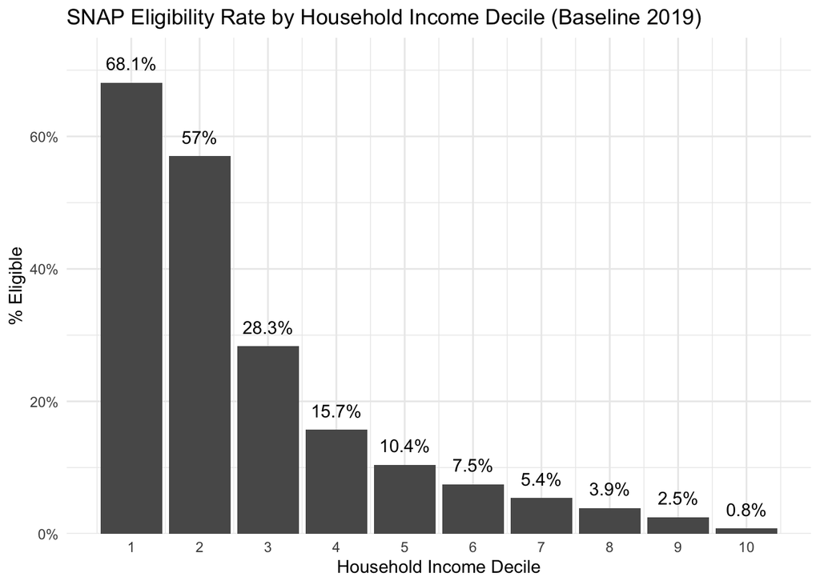

```r
distributional_table |>
  ggplot(aes(inc_decile, pct_eligible)) +
  geom_col() +
  geom_text(aes(label = paste0(pct_eligible, "%")), vjust = -1) +
  scale_x_continuous(breaks = 1:10) +
  scale_y_continuous(
    expand = expansion(mult = c(0, 0.1)),
    labels = scales::label_percent(scale = 1)) +
  labs(
    title = "SNAP Eligibility Rate by Household Income Decile (Baseline 2019)",
    x = "Household Income Decile",
    y = "% Eligible") +
  theme_minimal()
```

It’ll be difficult to demonstrate a change for every income decile, however in our analysis we can see that at least half in the bottom 20% of the distribution are eligible for SNAP and at least 10% of every decile in the bottom 50% is eligible for SNAP. As such the quartile distribution may be a better from of reference

**Quartile Distribution:**

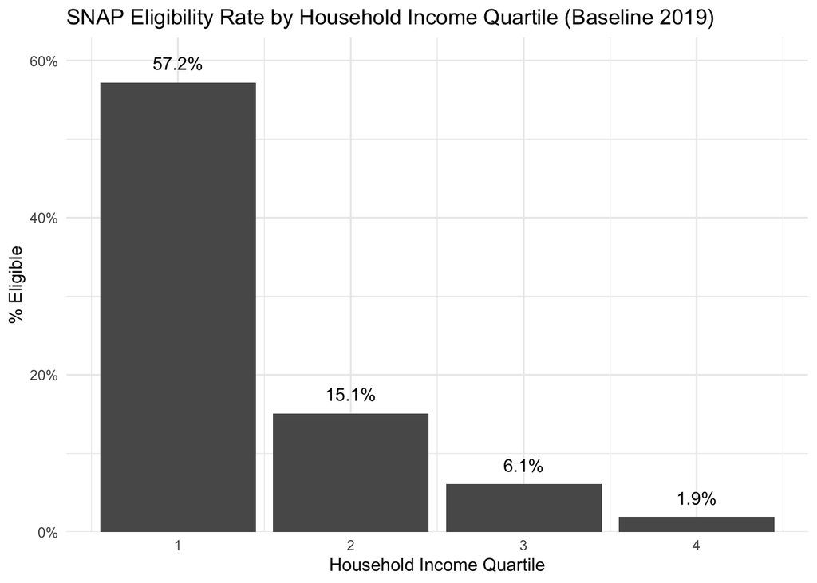

```r
quartile_distribution <- baseline |>
  mutate(inc_quartile = ntile(hh_gross_inc, n = 4)) |>
  group_by(inc_quartile) |>
  summarize(
    min_income = min(hh_gross_inc),
    max_income = max(hh_gross_inc),
    pct_eligible = round(weighted.mean(snap_eligible, weight, na.rm = TRUE) * 100, 1),
    n_eligible_weighted = sum(snap_eligible * weight, na.rm = TRUE)) |>
  ggplot(aes(inc_quartile, pct_eligible)) +
  geom_col() +
  geom_text(aes(label = paste0(pct_eligible, "%")), vjust = -1) +
  scale_x_continuous(breaks = 1:4) +
  scale_y_continuous(
    expand = expansion(mult = c(0, 0.1)),
    labels = scales::label_percent(scale = 1)) +
  labs(
    title = "SNAP Eligibility Rate by Household Income Quartile (Baseline 2019)",
    x = "Household Income Quartile",
    y = "% Eligible") +
  theme_minimal()

quartile_distribution
```

This suggests that the bottom quarter is most directly impacted by our SNAP eligibility formula. However, at least 15% of the next quartile is also impacted. We take the bottom quarter of the population and model how their eligibility changes nationally under the different simulation.

### Income Distribution of SNAP eligibility by Simulated Scenario

**Bottom Quartile by Simulation**

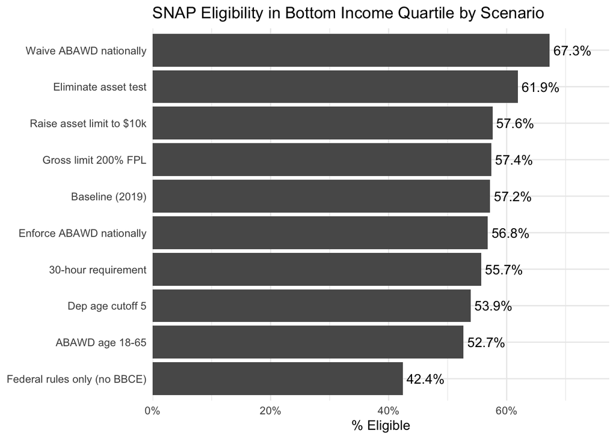

```r
bind_rows(baseline, income_200pct, income_no_bbce, asset_elim, asset_10k,
          work_waive, work_enforce, work_30hrs, work_dep5, work_age65) |>
  group_by(scenario) |>
  mutate(inc_quartile = ntile(hh_gross_inc, n = 4)) |>
  filter(inc_quartile == 1) |>
  summarize(
    pct_eligible = round(weighted.mean(snap_eligible, weight, na.rm = TRUE) * 100, 1)
  ) |>
  ggplot(aes(reorder(scenario, pct_eligible), pct_eligible)) +
  geom_col() +
  geom_text(aes(label = paste0(pct_eligible, "%")), hjust = -0.1) +
  coord_flip() +
  scale_y_continuous(
    expand = expansion(mult = c(0, 0.15)),
    labels = scales::label_percent(scale = 1)) +
  labs(
    title = "SNAP Eligibility in Bottom Income Quartile by Scenario",
    x = NULL,
    y = "% Eligible") +
  theme_minimal()
```

**Second Bottom Quartile by Simulation**

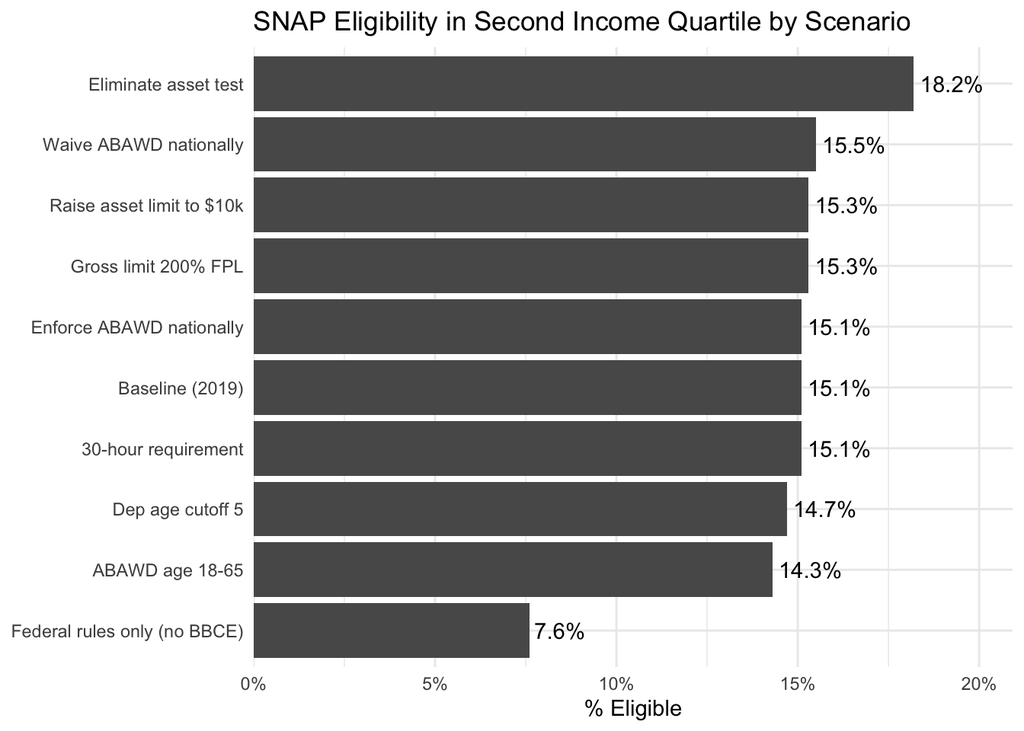

```r
bind_rows(baseline, income_200pct, income_no_bbce, asset_elim, asset_10k,
          work_waive, work_enforce, work_30hrs, work_dep5, work_age65) |>
  group_by(scenario) |>
  mutate(inc_quartile = ntile(hh_gross_inc, n = 4)) |>
  filter(inc_quartile == 2) |>
  summarize(
    pct_eligible = round(weighted.mean(snap_eligible, weight, na.rm = TRUE) * 100, 1)) |>
  ggplot(aes(reorder(scenario, pct_eligible), pct_eligible)) +
  geom_col() +
  geom_text(aes(label = paste0(pct_eligible, "%")), hjust = -0.1) +
  coord_flip() +
  scale_y_continuous(
    expand = expansion(mult = c(0, 0.15)),
    labels = scales::label_percent(scale = 1)) +
  labs(
    title = "SNAP Eligibility in Second Income Quartile by Scenario",
    x = NULL,
    y = "% Eligible") +
  theme_minimal()
```

Across the bottom half of the income distribution patterns emerge:

1. BBCE helps ensure lower income families can have access to food assistance and are the single biggest driver SNAP participation in our models.
2. OBBBA style reforms (ABAWD work requirements) are the most regressive and lower families SNAP eligibility across the board.
   1. **In the lowest quartile simply expanding the ABAWD age range from up to 49 to 65 means 5% of families in the lowest quartile lose SNAP.**

**We can also just for the sake of depth look at the distributions for each policy by quartile**

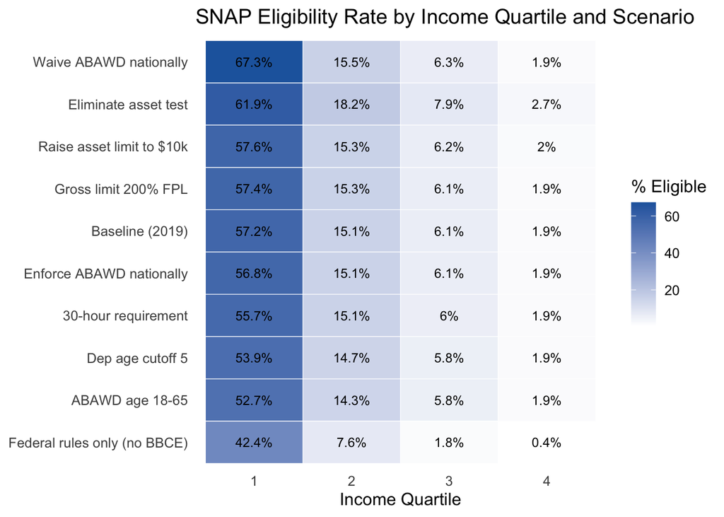

```r
bind_rows(baseline, income_200pct, income_no_bbce, asset_elim, asset_10k,
          work_waive, work_enforce, work_30hrs, work_dep5, work_age65) |>
  group_by(scenario) |>
  mutate(inc_quartile = ntile(hh_gross_inc, n = 4)) |>
  group_by(scenario, inc_quartile) |>
  summarize(
    pct_eligible = round(weighted.mean(snap_eligible, weight, na.rm = TRUE) * 100, 1),
    .groups = "drop") |>
  ggplot(aes(x = factor(inc_quartile), y = reorder(scenario, pct_eligible), fill = pct_eligible)) +
  geom_tile(color = "white") +
  geom_text(aes(label = paste0(pct_eligible, "%")), size = 3.2) +
  scale_fill_gradient(low = "white", high = "#2166ac",
                      name = "% Eligible") +
  labs(
    title = "SNAP Eligibility Rate by Income Quartile and Scenario",
    x = "Income Quartile",
    y = NULL
  ) +
  theme_minimal(base_size = 12) +
  theme(panel.grid = element_blank())
```

This generally doesn’t reveal anything too stark about SNAP however it does indicate that BBCE policies also affect those who aren’t necessarily in the bottom half of the distribution.

### Pseudo OBBBA ABAWD Work Requirement Simulation

All of the prior simulations only toggle one scenario at a time. However, if we edit the scenarios by raising the age of exemption to 65 and edit the dependent child clause to not exempt families where the youngest child is over 14 then we can somewhat model OBBBA. We can’t necessarily cover some of the provisions like stricter work waivers or cost share behavorial responses however.

```r
obbba_simulation <- run_scenario(hh_sipp, "OBBBA (approx.)",
                                 abawd_max_age = 65,
                                 dep_age = 14)
```

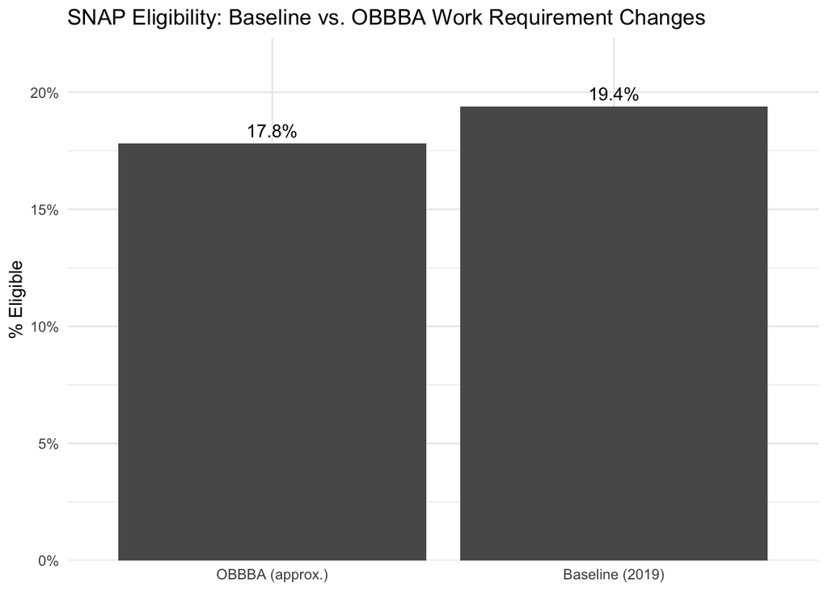

```r
bind_rows(
  summarize_scenario(baseline),
  summarize_scenario(obbba_simulation)) |>
  ggplot(aes(reorder(scenario, pct_eligible), pct_eligible)) +
  geom_col() +
  geom_text(aes(label = paste0(pct_eligible, "%")), vjust = -0.5) +
  scale_y_continuous(
    expand = expansion(mult = c(0, 0.15)),
    labels = scales::label_percent(scale = 1)) +
  labs(
    title = "SNAP Eligibility: Baseline vs. OBBBA Work Requirement Changes",
    x = NULL,
    y = "% Eligible") +
  theme_minimal()
```

## State-level eligibility estimations

### State-level results

Because states have different baseline eligibility rates, and baseline SNAP eligibility rules, we are also interested in summarizing how these different policy changes would change eligibility rates at the state level. We write a function to summarize the estimated number of eligible households for each state.

```r
summarize_by_state <- function(data) {
  data |>
    group_by(state_fips, scenario) |>
    summarize(
      n_eligible_weighted = sum(snap_eligible * weight, na.rm = TRUE),
      n_total_weighted    = sum(weight, na.rm = TRUE),
      pct_eligible = round(weighted.mean(snap_eligible, weight, na.rm = TRUE) * 100, 1),
      .groups = "drop"
    )
}
```

Next, we generate the same policy scenarios described above, but summarized for their impact on each state’s eligibility rates.

```r
# Baseline
baseline_state <- hh_sipp |>
  run_scenario("Baseline") |>
  summarize_by_state()

# Income
twohundred_state  <- hh_sipp |>
  run_scenario("Gross limit 200% FPL", gross_pct = 2.00) |>
  summarize_by_state()

no_bbce_state <- hh_sipp |>
  run_scenario("Federal rules only (no BBCE)", use_bbce = FALSE) |>
  summarize_by_state()

# Assets
asset_elim_state <- hh_sipp |>
  run_scenario("Eliminate asset test", elim_asset = TRUE) |>
  summarize_by_state()

asset_10k_state  <- hh_sipp |>
  run_scenario("Raise asset limit to $10k", asset_limit = 10000) |>
  summarize_by_state()

# Work requirement scenarios
work_waive_state <- hh_sipp |>
  run_scenario("Waive ABAWD nationally", work_req = "full_exemption") |>
  summarize_by_state()

work_enforce_state <- hh_sipp |>
  run_scenario("Enforce ABAWD nationally", work_req = "no_exemption") |>
  summarize_by_state()

work_30hrs_state <- hh_sipp |>
  run_scenario("30-hour requirement", min_work_hrs = 30) |>
  summarize_by_state()

work_dep5_state <- hh_sipp |>
  run_scenario("Dep age cutoff 5", dep_age = 5) |>
  summarize_by_state()

work_age65_state <- hh_sipp |>
  run_scenario("ABAWD age 18-65", abawd_max_age = 65) |>
  summarize_by_state()
```

```r
state_results <- bind_rows(baseline_state, twohundred_state,
                           no_bbce_state, asset_elim_state, asset_10k_state,
                           work_waive_state, work_enforce_state, work_30hrs_state,
                           work_dep5_state, work_age65_state) |>
  group_by(state_fips) |>
  mutate(change_from_baseline = n_eligible_weighted - n_eligible_weighted[scenario == "Baseline"],
         pct_change = round(100 * change_from_baseline / n_eligible_weighted[scenario == "Baseline"],1)) |>
  ungroup() |>
  arrange(state_fips)

state_results
```

```
# A tibble: 510 × 7
   state_fips scenario         n_eligible_weighted n_total_weighted pct_eligible
        <int> <chr>                          <dbl>            <dbl>        <dbl>
 1          1 Baseline                     554787.         2129374.         26.1
 2          1 Gross limit 200…             554787.         2129374.         26.1
 3          1 Federal rules o…             378018.         2129374.         17.8
 4          1 Eliminate asset…             554787.         2129374.         26.1
 5          1 Raise asset lim…             554787.         2129374.         26.1
 6          1 Waive ABAWD nat…             639695.         2129374.         30
 7          1 Enforce ABAWD n…             554787.         2129374.         26.1
 8          1 30-hour require…             540595.         2129374.         25.4
 9          1 Dep age cutoff 5             539809.         2129374.         25.4
10          1 ABAWD age 18-65              504942.         2129374.         23.7
# ℹ 500 more rows
# ℹ 2 more variables: change_from_baseline <dbl>, pct_change <dbl>
```

## References

FNS. 2018. “SNAP Fiscal Year 2019 Cost-of-Living Adjustments.” https://fns-prod.azureedge.us/snap/fy-2019-cost-living-adjustments.

———. 2025a. “Reaching Those in Need: Estimates of USDA’s SNAP Program Participation Rates in 2019 | Food and Nutrition Service.” https://www.fns.usda.gov/research/snap/state-participation-rates/2019.

———. 2025b. “SNAP Data Tables | Food and Nutrition Service.” https://www.fns.usda.gov/pd/supplemental-nutrition-assistance-program-snap.

HHS. 2019. “2019 Poverty Guidelines.” http://aspe.hhs.gov/topics/poverty-economic-mobility/poverty-guidelines/prior-hhs-poverty-guidelines-federal-register-references/2019-poverty-guidelines.

Meyer, Bruce D., Wallace K. C. Mok, and James X. Sullivan. 2015. “Household Surveys in Crisis.” *Journal of Economic Perspectives* 29 (4): 199–226. https://doi.org/10.1257/jep.29.4.199.

US Census Bureau. 2024. “2024 Survey of Income and Program Participation,” 161. https://www2.census.gov/programs-surveys/sipp/tech-documentation/methodology/2024_SIPP_Users_Guide.pdf.